# Introduction to mrgsolve

# What can you do with mrgsolve?

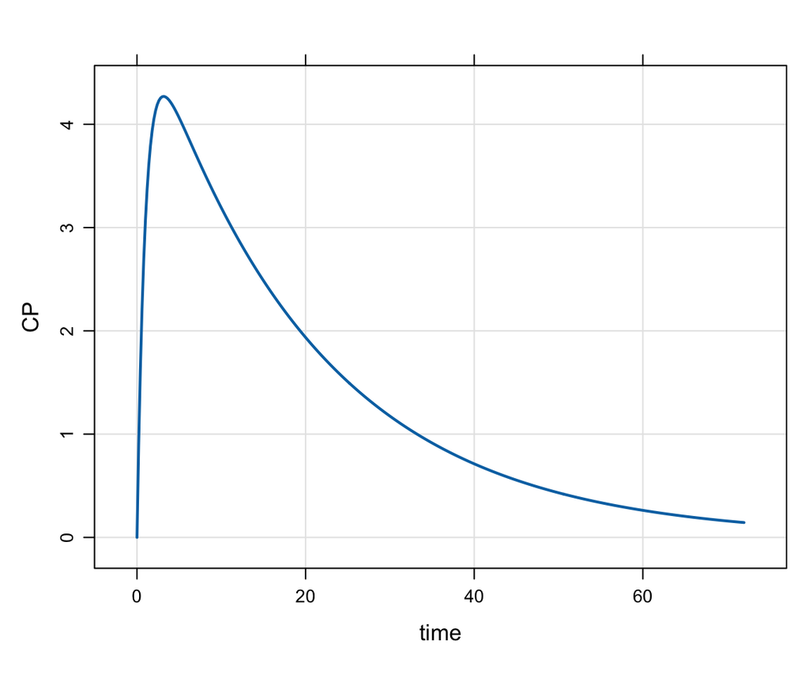

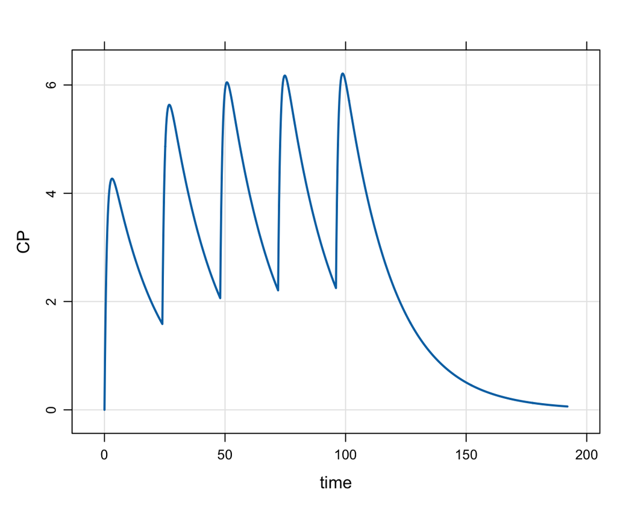

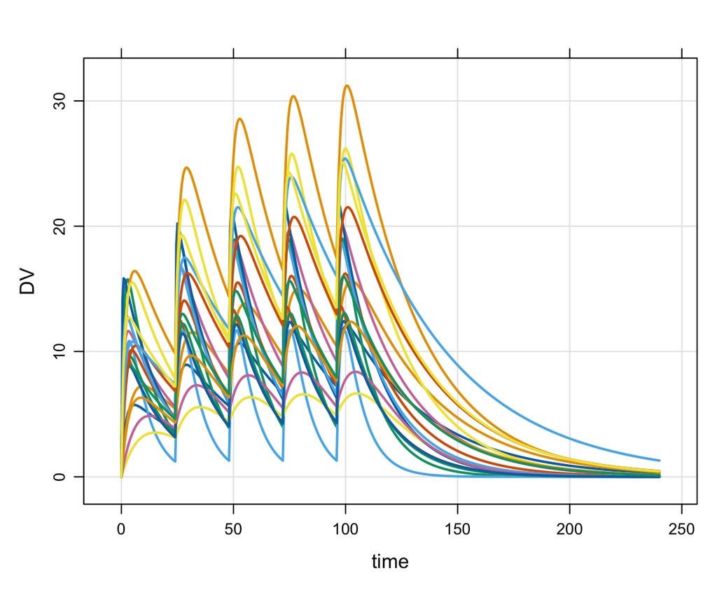

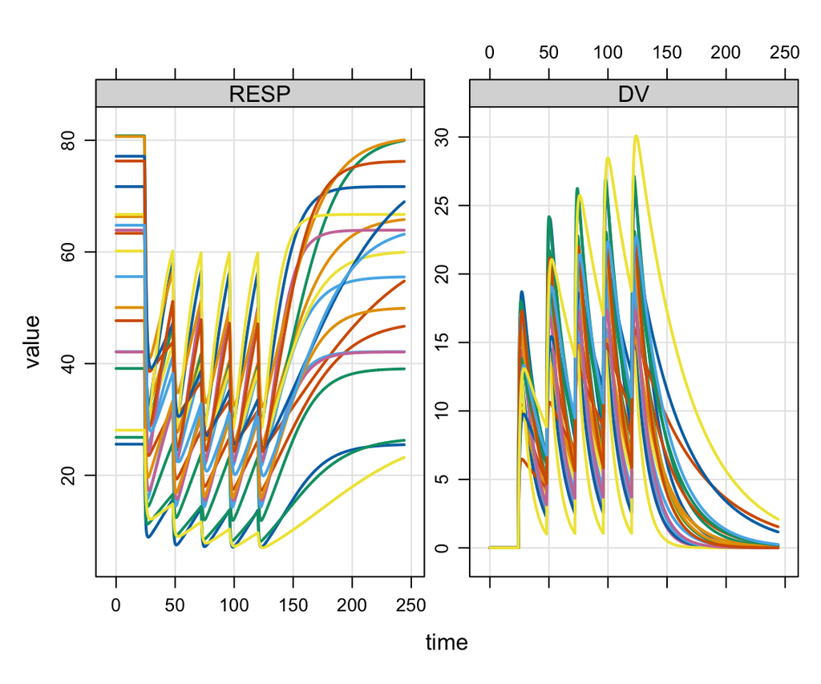

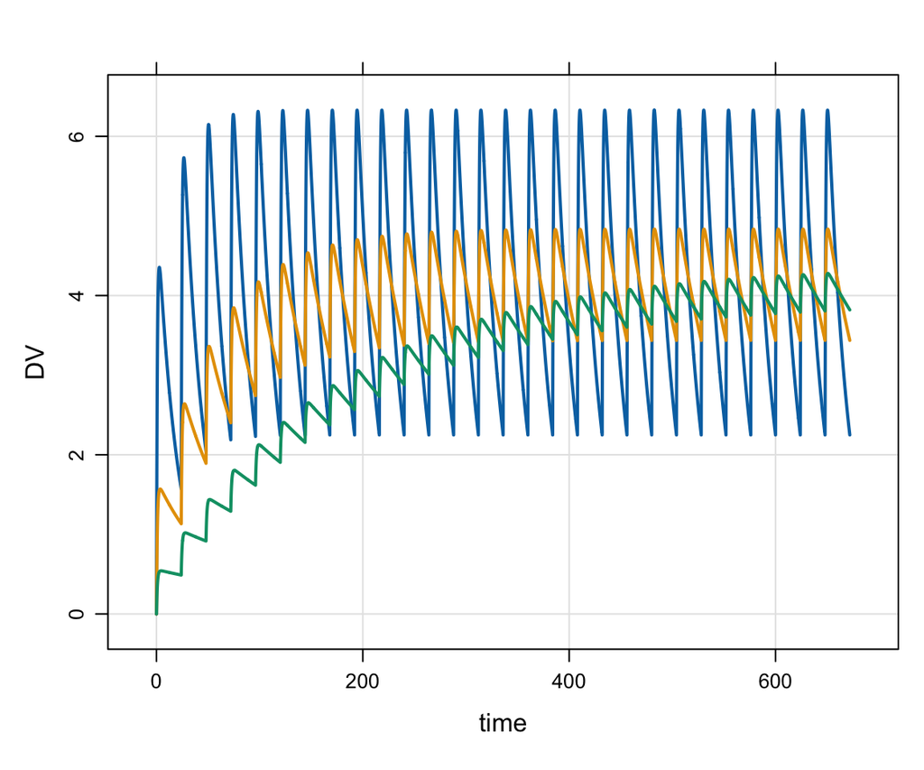

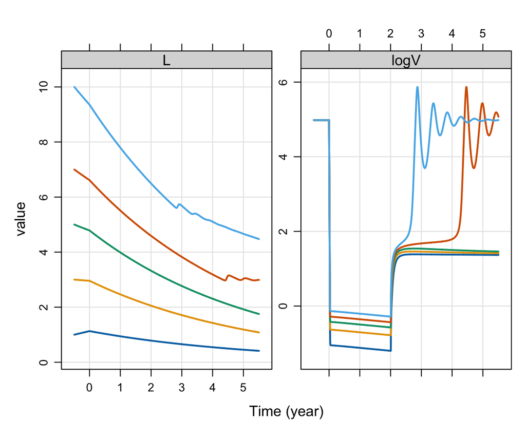

# About `mrgsolve`

- `R` package for simulation from ODE-based models
  - Free, OpenSource, GitHub, CRAN
- Language
  - Models written in `C++` inside model specification format
  - General purpose solver: `ODEPACK` / `DLSODA` (`FORTRAN`)
    - Automatically detect and switch between non-stiff (Adams) and stiff (BDF) methods for solving the differential equations
  - Simulation workflow in `R`
- Hierarchical (population) simulation
  - `ID`, $\eta$, $\varepsilon$
- Integrated PK functionaility
  - Bolus, infusion, `F`, `ALAG`, `SS` etc, handled under the hood
  - 1- and 2-cmt PK models in closed-form
- Extensible using `R`, `C++`, `Rcpp`, `boost`, `RcppArmadillo`
- `R` is it’s natural habitat

# `mrgsolve` started as `QSP` modeling tool

- Motivation: large bone/mineral homeostatsis model (CaBone)
- History using
  - Berkeley Madonna
  - WinBUGS
  - NONMEM (attempted)
- 2010: write `R` front end to `deSolve`
- 2012: write `C++` interface to `DLSODA`
- Develop dosing / event capability
- More recently, expose functionality provided by
  - `Rcpp` - vectors, matrices, functions, environments, random numbers
  - `boost` - numerical tools in `C++`
  - users’ own `C++` code (functions, data structures, classes)
- Translator from `SBML` to `mrgsolve` using `R` bindings to `libSBML`

# Orientation

- https://CRAN.R-project.org/package=mrgsolve
- GitHub site: https://github.com/metrumresearchgroup/mrgsolve
- Discussion: https://github.com/metrumresearchgroup/mrgsolve/discussions
- Issues: https://github.com/metrumresearchgroup/mrgsolve/issues
- mrgsolve website: https://mrgsolve.org
- User Guide: https://mrgsolve.org/user_guide
- Blog: https://mrgsolve.org/blog
- Vignettes: https://mrgsolve.org/vignettes

# R for Data Science

https://r4ds.had.co.nz/

# What we will cover today

1. Three basic workflows
2. Loading the model into R
3. Event objects
4. Data sets
5. Model specification - code together
6. Whatever you ask about

# A basic simulation with mrgsolve

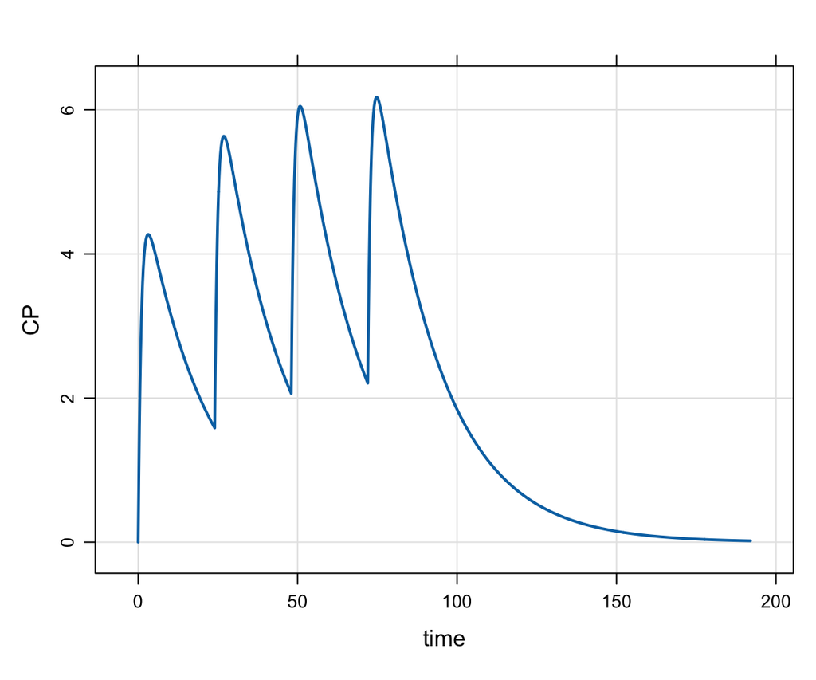

```r
mod %>% ev(amt = 100, ii = 24, addl = 3) %>% mrgsim() %>% plot()
```

# A basic simulation with mrgsolve

```r
mod %>% ev(amt = 100, ii = 24, addl = 3) %>% mrgsim() %>% plot()
```

- mod: the model object
  - Ok … where did `that` come from?
- ev(amt = 100, …) : the intervention
  - An `event` in this example
- mrgsim(): actually do the simulation
- plot(): do something with the simulation
  - `plot`, `mutate`, `as_tibble` etc …
> - model `%>%` intervention `%>%` Go! `%>%` take-a-look

# What’s coming …

> - `model %>% intervention %>%` options `%>% Go! %>% ...`
> - `model %>% intervention %>%` population `%>% Go! %>% ...`
> - `model %>%` data-set `%>% Go! %>% ...`
> - where data-set = `intervention + population`
> - For now, let’s get this part down
> - model `%>%` intervention `%>%` Go! `%>%` take-a-look

# Why do we use `%>%` ?

What happens first in this operation?

```r
mean(sqrt(seq(4)))
```

# Pipelines

```r
mean(sqrt(seq(4)))
```

```r
4  %>% seq() %>% sqrt() %>% mean()
```

Better.

```r
4  %>%
  seq(.) %>%
  sqrt(.) %>%
  mean(., na.rm = TRUE)
```

```r
mod %>% some_intervention() %>% simulate() %>% post_process()
```

# The model object

model `%>% ...`

> - I (almost) always call the model object mod in the documention / examples
> - All the information about the model we need to know to run the simulation
> - Distinct from the intervention, the population, the summary
> - But the model does know about output time, random effects

# Take a look: overview

```r
mod
```

```
-----------------  source: pk1.cpp  -----------------

  project: /Users/ahmede/Li...gsolve/models
  shared object: pk1-so-853b215d7005

  time:          start: 0 end: 192 delta: 0.2
                 add: <none>

  compartments:  EV CENT [2]
  parameters:    CL V KA [3]
  captures:      CP [1]
  omega:         0x0
  sigma:         0x0

  solver:        atol: 1e-08 rtol: 1e-08 maxsteps: 20k
------------------------------------------------------
```

# Take a look: parameters (really important)

```r
param(mod)
```

```
 Model parameters (N=3):
 name value . name value
 CL   1     | V    20
 KA   1     | .    .
```

> - Parameters get a name
> - Names and number of parameters gets fixed at compile time
> - All parameters have a value
> - Value can be modified after compile time

# Take a look: compartments

```r
init(mod)
```

```
 Model initial conditions (N=2):
 name       value . name     value
 CENT (2)   0     | EV (1)   0
```

> - Every compartment gets a name
> - Every compartment gets an initial condition

# Where did mod come from?

```r
mod <- mread("simple", "model")
```

```r
mod <- mread("<model-name>", "<project-directory>")
```

- By default mrgsolve looks for the code in the file
  - model-name.cpp in
  - project-directory
- mread demo

# Read in a model object with caching

First time to read

```r
mod <- mread_cache("simple", here("day1/model"))
```

```
. Building simple ... done.
```

Next time to read

```r
mod <- mread_cache("simple", here("day1/model"))
```

```
. Loading model from cache.
```

# Model build directory (`soloc`)

It can be helpful to set

```r
options(mrgsolve.soloc = "my_build_directory")
```

Equivalent to

```r
mod <- mread("simple", here("day1/model"), soloc = "my_build_directory")
```

# Internal model library

```r
mod <- mread("<first-argument>", "<second-argument>")
```

# Internal model library

```r
mod <- mread("<first-argument>", "<second-argument>")
```

```r
mod <- mread("<first-argument>", modlib())
```

```r
modlib()
```

```
. [1] "/Users/ahmede/Library/Caches/org.R-project.R/R/renv/cache/v5/macos/R-4.4/aarch64-apple-darwin23.4.0/mrgsolve/1.5.1/689a814a168f375aa0ebfeeb3ee78394/mrgsolve/models"
```

# Internal model library

```r
mod <- mread("effect", modlib())
```

```r
mod
```

```
.
.
. ----------------  source: effect.cpp  ----------------
.
.   project: /Users/ahmede/Li...gsolve/models
.   shared object: effect-so-853b1593bf41
.
.   time:          start: 0 end: 36 delta: 0.1
.                  add: <none>
.
.   compartments:  GUT CENT PERIPH CE [4]
.   parameters:    VC KA K10 K12 K21 E0 EMAX EC50 KEO [9]
.   captures:      EFFECT CP [2]
.   omega:         0x0
.   sigma:         0x0
.
.   solver:        atol: 1e-08 rtol: 1e-08 maxsteps: 20k
. ------------------------------------------------------
```

# Try this now

Open R script in Rstudio then …

```r
library(mrgsolve)
```

```r
mod <- mread("pbpk", modlib())
```

```r
mod <- modlib("pbpk")
```

# Your turn

- File name: day1/exercises/warm_up.R
- Section name: Warm Up